# Assignment 1

Derek Rouch

LLO 8200

Introduction to Data Science

August 25, 2019

## 1) A sentence that says “Hello, World”

```r
'Hello, World'
```

```
## [1] "Hello, World"
```

## 2) R output that summarizes the variables in the `college.Rdata` dataset

To begin, I will clear my Global Environment and get the library for the `tidyverse` package, which has already been installed.

```r
## Clear environment
rm(list=ls())
## Get tidyverse library
library(tidyverse)
```

Then, I need to load the `college.Rdata` dataset.

```r
## Load in the data
load("~/data-science/college.Rdata")
```

### Finding Average Earnings by College Selectivity

To find the average earnings based on admission selectivity, I can filter out colleges according to their admission rates. I’ll define the most selective schools as those that admit less than 10% of applicants *(adm_rate<.1)*, and the least selective schools that admit more than 30% *(adm_rate>.3)* of their applicants.

```r
## Average earnings for most selective colleges in dataset (admin rate of 10% or less)
sc%>%filter(adm_rate<.1)%>%summarize(mean_earnings=mean(md_earn_wne_p6,na.rm=TRUE))
```

```
## # A tibble: 1 x 1
##   mean_earnings
##           <dbl>
## 1         53500
```

```r
## Average earnings for least selective colleges in dataset (admin rate of 30% or more)
sc%>%filter(adm_rate>.3)%>%summarize(mean_earnings=mean(md_earn_wne_p6,na.rm=TRUE))
```

```
## # A tibble: 1 x 1
##   mean_earnings
##           <dbl>
## 1        34747.
```

### Comparing Average Earnings

To find the difference in average earnings between the most selective *(adm_rate<.1)* and least selective *(adm_rate>.3)* colleges, I can simply subtract these filtered means.

```r
## Difference in average earnings between most selective and least selective colleges in dataset
sc%>%filter(adm_rate<.1)%>%summarize(mean_earnings=mean(md_earn_wne_p6,na.rm=TRUE))-sc%>%filter(adm_rate>.3)%>%summarize(mean_earnings=mean(md_earn_wne_p6,na.rm=TRUE))
```

```
##   mean_earnings
## 1      18752.86
```

This shows us that graduates from selective schools have average earnings that are $18,752.86 higher than the average earnings of graduates from less selective schools.

### SAT Scores and College Size

To determine whether colleges with very high SAT scores tend to be larger or smaller than colleges with low SAT scores, I first plotted the variables to visually inspect whether a relationship was obvious.

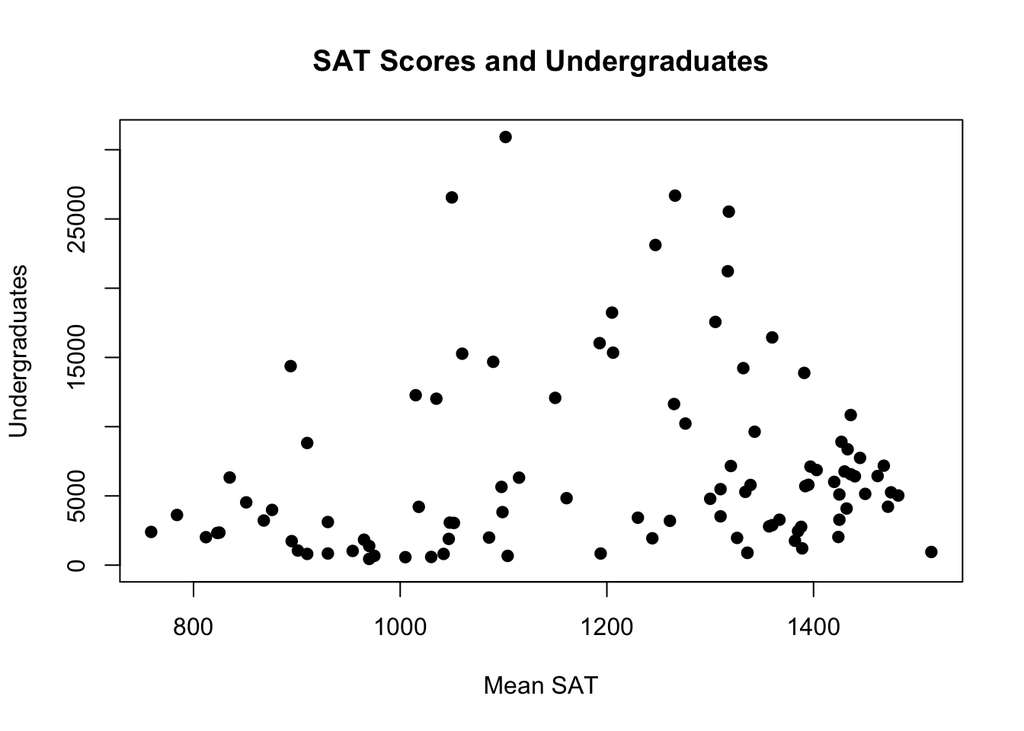

```r
## Plot of SAT Scores and College Size
plot(sc$sat_avg, sc$ugds,main="SAT Scores and Undergraduates", xlab="Mean SAT", ylab="Undergraduates", pch=19)
```

Although there did not appear to be a correlation, I also ran the `cor.test` function to test for association between average SAT scores and the number of undergraduates enrolled.

```r
## Pearson Correlation test
cor.test(sc$sat_avg, sc$ugds)
```

```
##
##  Pearson's product-moment correlation
##
## data:  sc$sat_avg and sc$ugds
## t = 1.3208, df = 96, p-value = 0.1897
## alternative hypothesis: true correlation is not equal to 0
## 95 percent confidence interval:
##  -0.06659166  0.32344133
## sample estimates:
##       cor
## 0.1335943
```

The `cor.test` confirmed that there is no relationship between average SAT scores and the number of undergraduates enrolled at a college, r(96) = 0.134, p > .05.

### Cost and Debt

To see the relationship between *average cost of attendance (tuition and room and board less all grant aid)* and *median debt of graduates*, I plotted the two variabes using the `plot` function.

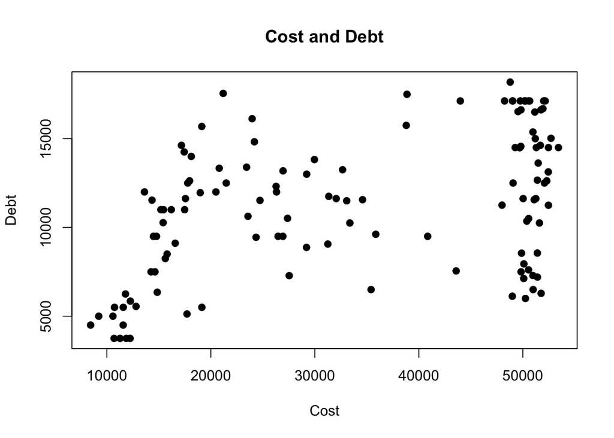

```r
## Plot of Cost and Debt
plot(sc$costt4_a, sc$debt_mdn,main="Cost and Debt", xlab="Cost", ylab="Debt", pch=19)
```

It’s apparent from the plot that a positive relationship exists between a college’s cost and the debt incurred by its students. This is not surprising.

### Cost and Debt by Control of Institution

To plot the cost and debt relationship by control of institution, I first passed the `sc` data set through a `filter` for control of instituion. I then assigned the filtered results a name *(public, private_np, and private_fp) before executing a `plot` function. For example, to plot the cost/debt relationship for public institutions, I set the `control` paraemeter equal to 1.

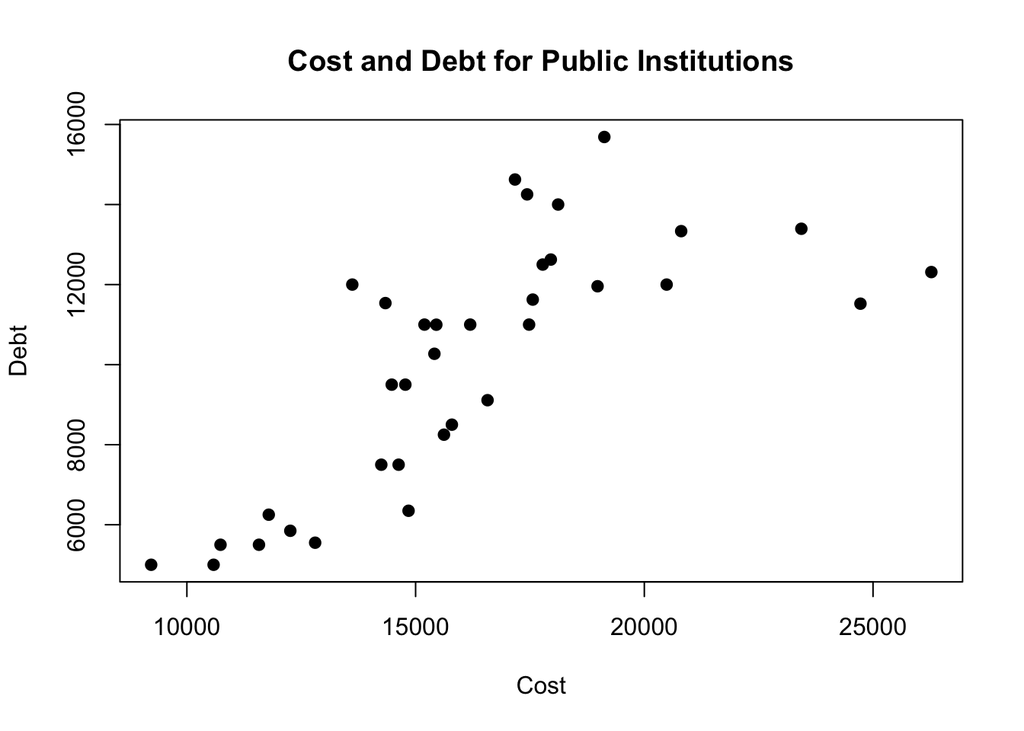

```r
## Plot of cost and debt for public institutions
public <- sc%>%filter(control==1)

plot(public$costt4_a, public$debt_mdn, main="Cost and Debt for Public Institutions", xlab="Cost", ylab="Debt", pch=19)
```

To plot the cost/debt relationship for private non-profit institutions, I set the `control` paraemeter equal to 2.

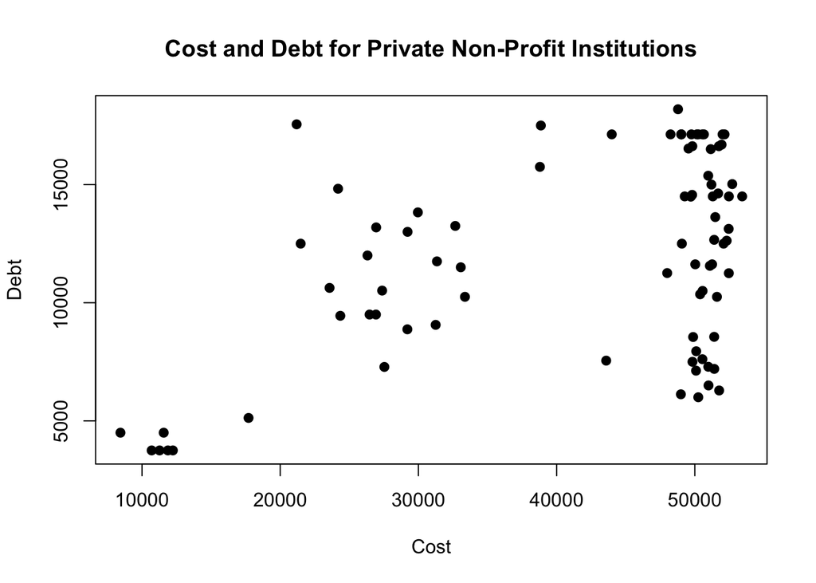

```r
## Plot of cost and debt for private non-profit institutions
private_np <- sc%>%filter(control==2)

plot(private_np$costt4_a, private_np$debt_mdn,main="Cost and Debt for Private Non-Profit Institutions", xlab="Cost", ylab="Debt", pch=19)
```

Finally, to plot the cost/debt relationship for private for-profit institutions, I set the `control` paraemeter equal to 3.

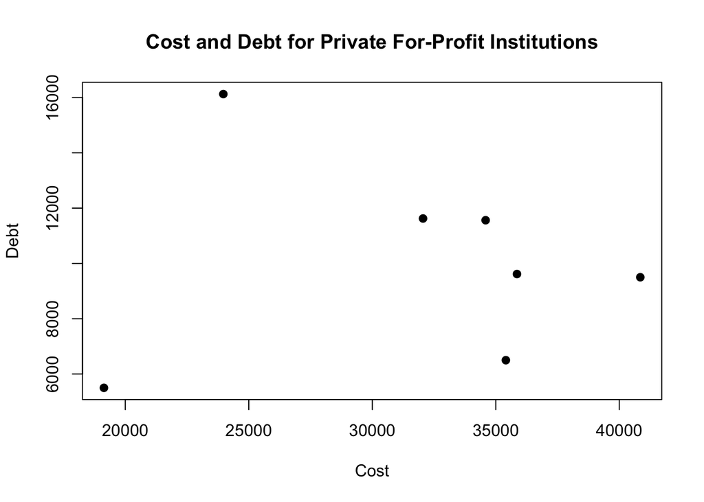

```r
## Plot of cost and debt for private for-profit institutions
private_fp <- sc%>%filter(control==3)

plot(private_fp$costt4_a, private_fp$debt_mdn,main="Cost and Debt for Private For-Profit Institutions", xlab="Cost", ylab="Debt", pch=19)
```